# Machine Learning in Python - KNN

Python

Quarto

Machine Learning

Author

Kyle Grealis

Published

April 19, 2024

## What is KNN?

In this post, I’m sharing the code that was created from following Kirill Eremenko and the SuperDataScience Team’s “Machine Learning A-Z” course on [Udemy](https://www.udemy.com/share/101Wci3@tAEY1lIEWWOQUxgTL4Ik8e59A6uu7QPTXm_rtWFphiUAplRw_mYHYKk1ACy8OBd_Kw==/).

The prediction scenario is this: which demographic would social networking marketing ads affect best? We work for a car dealership and have data regarding consumers’ age and estimated salary. To where should marketing efforts be aimed as we try to predict which consumers will purchase our newest & best SUV model?

Euclidean Distance between two points: $\sqrt{(x_2 - x_1)^2 + (y_2 - y_1)^2}$

*k*-Nearest Neighbors (KNN) is machine learning technique used to classify a new data point to a nearby cluster. We will set up our algorithm to calculate the Euclidean distances from our new data point to existing data points. Then, using the predetermined *k* number of nearest neighbors (we’ll be using 5 neighbors), assign that new point to the closest cluster with at least three like $>k/2$ neighbors.

To think of it in really simple terms, all of our existing customers (points) are scattered in the $(x, y)$ space. Our new customer has $x$ age and $y$ salary, so we’ll plot this onto our existing grid. Then we draw circles around the new customer until we hit the closest existing point – that’s one “neighbor”. We repeat the process until we have our chosen number of 5. How many of the neighbors purchased the SUV and how many did not? Whichever group has more, that’s what we’re going to predict the new customer would do too!

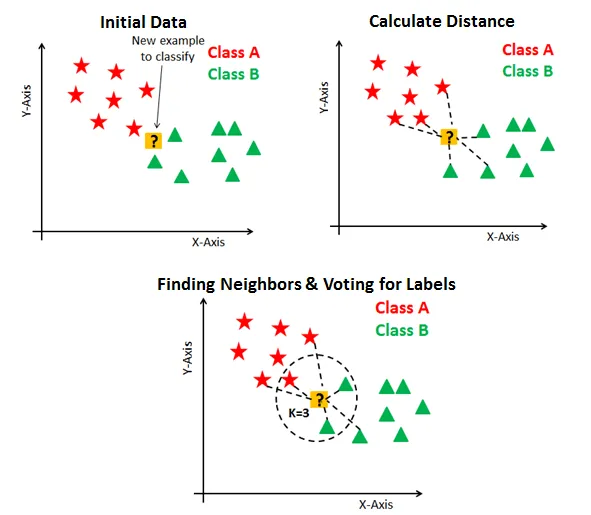

*Courtesy of [DataCamp](https://www.datacamp.com)*

## Import libraries

```python
import numpy as np
import pandas as pd
```

## Import dataset

```python
dataset = pd.read_csv('data/Social_Network_Ads.csv')
X = dataset.iloc[:, :-1].values
y = dataset.iloc[:, -1].values
```

## Splitting the dataset to training & testing

```python
from sklearn.model_selection import train_test_split
X_train, X_test, y_train, y_test = train_test_split(
  X, y,
  test_size=0.25,
  random_state=0
)
```

## Feature scaling

```python
from sklearn.preprocessing import StandardScaler
sc = StandardScaler()
X_train = sc.fit_transform(X_train)
X_test = sc.fit_transform(X_test)
```

````markdown
```
# array([[-1.455..., -0.784...],
#        [ 2.067...,  1.372...],
#        [-0.253..., -0.309...],
#        ...,
#        [-0.253..., -0.309...],
#        [ 2.067..., -1.113...],
#        [-1.455..., -0.309...]])
```
````

## Train & fit the KNN model

**Tip**

To learn the more technical details of `sklearn`’s classes and functions, checkout the [`sklearn` API Reference](https://scikit-learn.org/1.4/modules/classes.html).

```python
from sklearn.neighbors import KNeighborsClassifier
classifier = KNeighborsClassifier(
  n_neighbors=5,  # default
  p=2,            # euclidean distance; default
  metric='minkowski'
)
```

```python
classifier.fit(X_train, y_train)
```

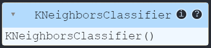

## Predicting a new result

30y/o $87k/yr – first observation of X_test

```python
person = X_test[[0]]
single_pred = classifier.predict(person)
single_prob = classifier.predict_proba(person)
print('1="Yes", 0="No"\n')
print(f'Single prediction for 30 y/o earning $87k/yr: {single_pred[0]} at a probability of {single_prob[0][0].round(3)}')
```

````markdown
```
# 1="Yes", 0="No"
#
# Single prediction for 30 y/o earning $87k/yr: 0 at a
# probability of 0.8
```
````

## Predicting the test set results

```python
y_pred = classifier.predict(X_test)
```

## Creating the confusion matrix

```python
from sklearn.metrics import confusion_matrix, accuracy_score
print(confusion_matrix(y_test, y_pred))
print(f'Accuracy: {accuracy_score(y_test, y_pred)}')
```

````markdown
```
# [[64  4]
#  [ 3 29]]
# Accuracy: 0.93
```
````

## Visualizing the training set results

**Warning**

These next two code chunks will take a while. The KNN algorithm is already compute-expensive and we’re adding to the heavy lifting by creating a grid of many values to be calculated. The final result is two plots with a visual mapping of our decision boundary **and** our training & predicted data points appearing as the dots within the field.

```python
import matplotlib.pyplot as plt
from matplotlib.colors import ListedColormap

X_set, y_set = sc.inverse_transform(X_train), y_train
X1, X2 = np.meshgrid(
  np.arange(
    start = X_set[:, 0].min() - 10,
    stop = X_set[:, 0].max() + 10,
    step = 0.25
  ),
  np.arange(
    start = X_set[:, 1].min() - 1000,
    stop = X_set[:, 1].max() + 1000,
    step = 0.25
  )
)
plt.contourf(
  X1, X2,
  classifier.predict(
    sc.transform(np.array([X1.ravel(), X2.ravel()]).T)
  ).reshape(X1.shape),
  alpha = 0.75,
  cmap = ListedColormap(('red', 'green'))
)

plt.xlim(X1.min(), X1.max())
plt.ylim(X2.min(), X2.max())

for i, j in enumerate(np.unique(y_set)):
  plt.scatter(
    X_set[y_set == j, 0],
    X_set[y_set == j, 1],
    c = ListedColormap(('red', 'green'))(i),
    label = j
  )

plt.title('KNN Regression (Training set)')
plt.xlabel('Age')
plt.ylabel('Estimated Salary')
plt.legend()
plt.show()
```

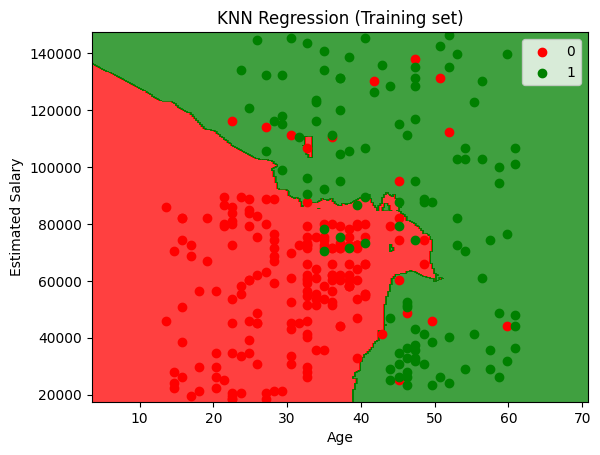

KNN training set results

## Visualizing the test set results

```python
X_set, y_set = sc.inverse_transform(X_test), y_test
X1, X2 = np.meshgrid(
  np.arange(
    start = X_set[:, 0].min() - 10,
    stop = X_set[:, 0].max() + 10,
    step = 0.25
  ),
  np.arange(
    start = X_set[:, 1].min() - 1000,
    stop = X_set[:, 1].max() + 1000,
    step = 0.25
  )
)
plt.contourf(
  X1, X2,
  classifier.predict(
    sc.transform(np.array([X1.ravel(), X2.ravel()]).T)
  ).reshape(X1.shape),
  alpha = 0.75,
  cmap = ListedColormap(('red', 'green'))
)

plt.xlim(X1.min(), X1.max())
plt.ylim(X2.min(), X2.max())

for i, j in enumerate(np.unique(y_set)):
    plt.scatter(
      X_set[y_set == j, 0],
      X_set[y_set == j, 1],
      c = ListedColormap(('red', 'green'))(i),
      label = j
    )

plt.title('KNN Regression (Test set)')
plt.xlabel('Age')
plt.ylabel('Estimated Salary')
plt.legend()
plt.show()
```

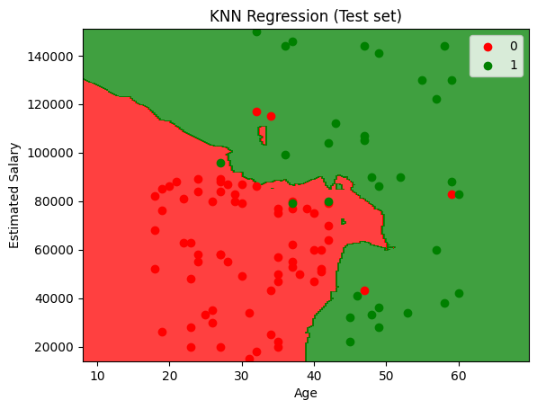

KNN testing set results

Share your insights at kylegrealis@proton.me. Together, we can make our R projects more robust, reproducible, and ready for collaboration!

Happy coding!

~Kyle